# Customer Segmentation Report

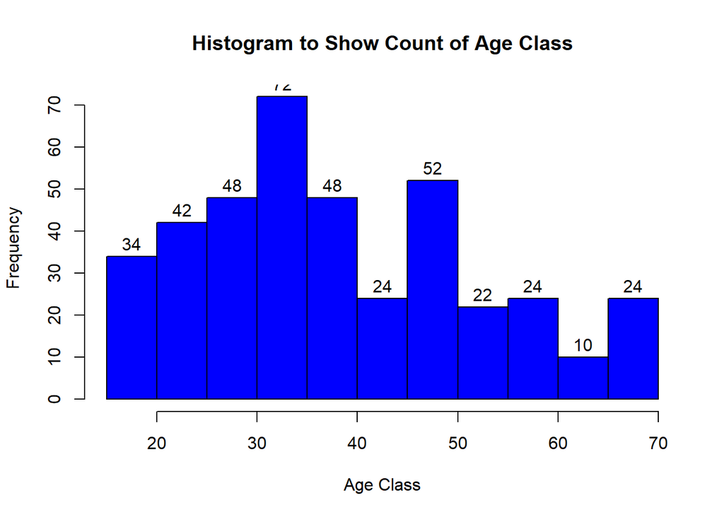

```r
hist(customer_data$Age,
     col="blue",
     main="Histogram to Show Count of Age Class",
     xlab="Age Class",
     ylab="Frequency",
     labels=TRUE)
```

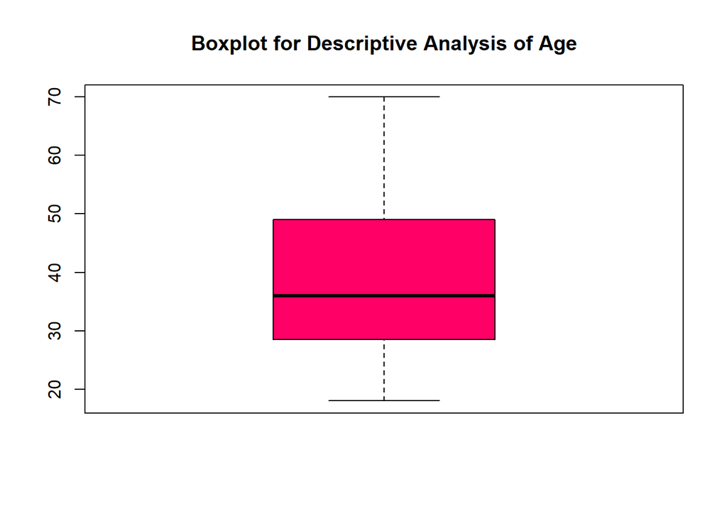

```r
boxplot(customer_data$Age,
        col="#ff0066",
        main="Boxplot for Descriptive Analysis of Age")
```

**Analysis of the Annual income of the Customers**  
I conducted visualizations to analyze the annual income of the customers. Below are the key findings:

Histogram:  
By plotting a histogram, I observed the distribution of annual incomes among the customers. The analysis revealed that the minimum annual income is 15, and the maximum income is 137. The histogram showed that individuals earning an average income of 70 had the highest frequency count. The average salary of all customers in the dataset is 60.56.

These visualizations provided valuable insights into the distribution and characteristics of customer annual incomes in my project.

```r
summary(customer_data$Annual.Income..k..)
```

```
##    Min. 1st Qu.  Median    Mean 3rd Qu.    Max.
##   15.00   41.50   61.50   60.56   78.00  137.00
```

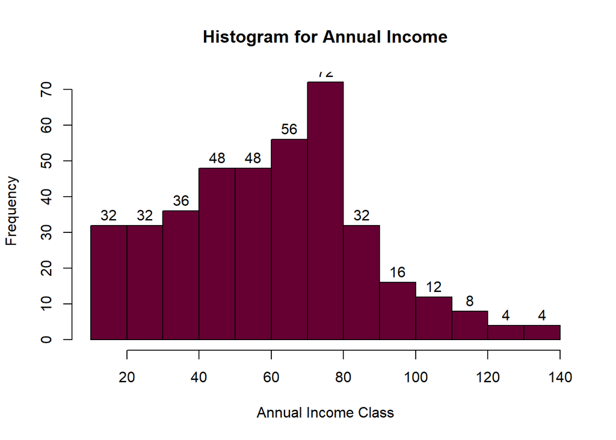

```r
hist(customer_data$Annual.Income..k..,
     col="#660033",
     main="Histogram for Annual Income",
     xlab="Annual Income Class",
     ylab="Frequency",
     labels=TRUE)
```

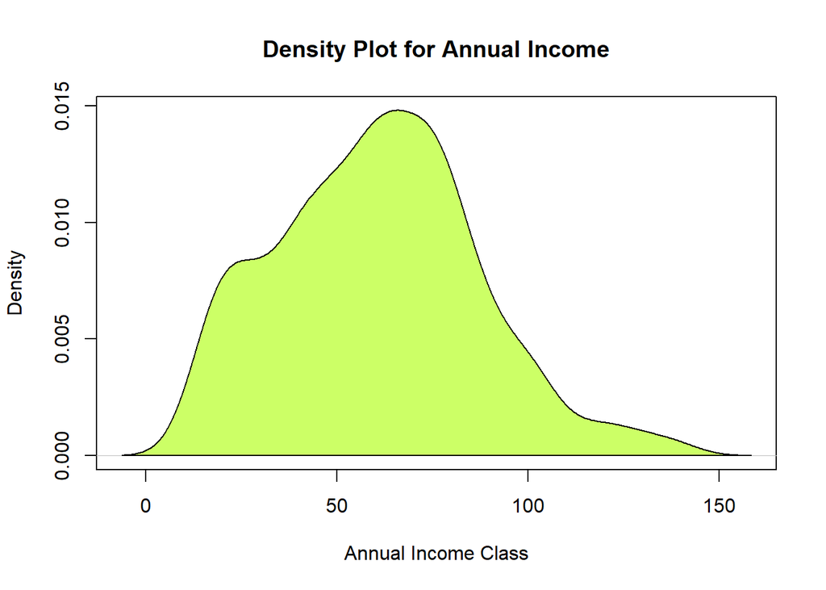

```r
plot(density(customer_data$Annual.Income..k..),
     col="yellow",
     main="Density Plot for Annual Income",
     xlab="Annual Income Class",
     ylab="Density")
polygon(density(customer_data$Annual.Income..k..),
        col="#ccff66")
```

**Analysis of the Annual Expenditure of the customers**  
I used a histogram and a boxplot to analyze the annual expenditure (Spending Score) of customers. The histogram provided insights into the distribution of spending scores, showing the majority of customers clustered around the median value of 50.00. The boxplot revealed the central tendency and variability of the data, including the minimum, maximum, median, and quartiles. These visualizations provided a comprehensive understanding of customer spending behavior, highlighting the range, concentration, and potential outliers in annual expenditure.

```r
summary(customer_data$Spending.Score..1.100)
```

```
##    Min. 1st Qu.  Median    Mean 3rd Qu.    Max.
##    1.00   34.75   50.00   50.20   73.00   99.00
```

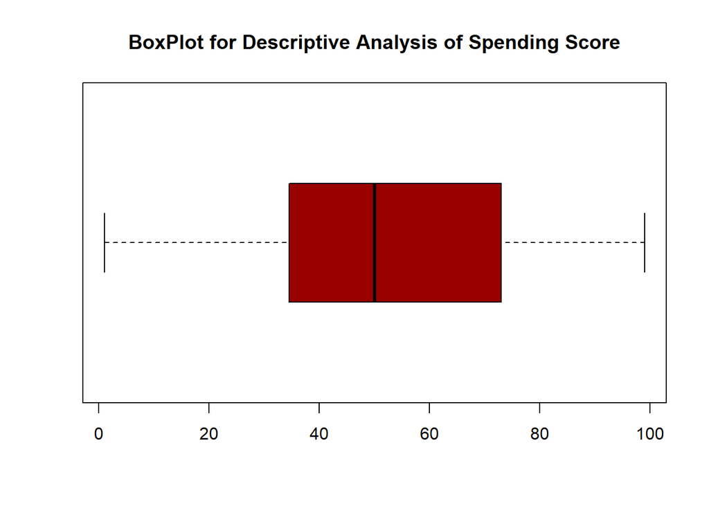

```r
boxplot(customer_data$Spending.Score..1.100.,
        horizontal=TRUE,
        col="#990000",
        main="BoxPlot for Descriptive Analysis of Spending Score")
```

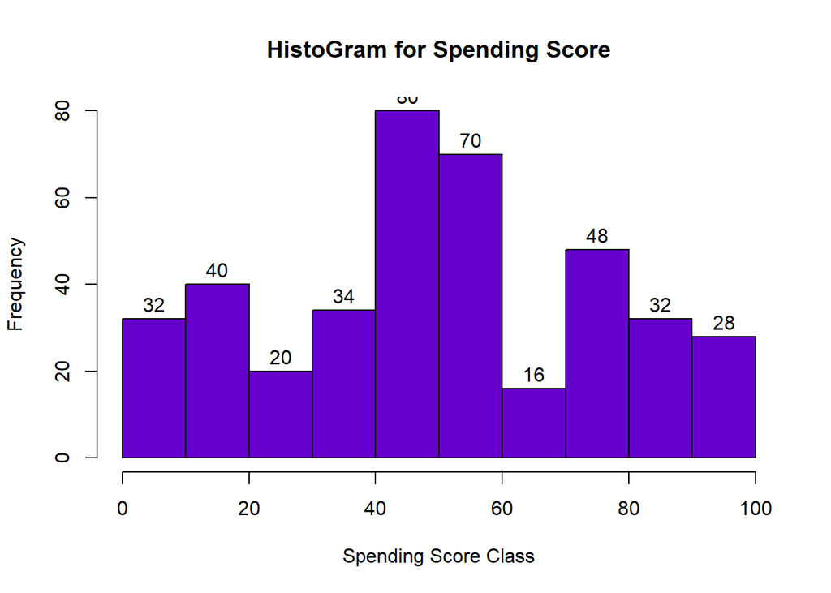

```r
hist(customer_data$Spending.Score..1.100.,
     main="HistoGram for Spending Score",
     xlab="Spending Score Class",
     ylab="Frequency",
     col="#6600cc",
     labels=TRUE)
```

**K-Means Algorithm**  
I applied the K-means clustering algorithm to group data points into clusters. The algorithm involved the following steps:

1. Number of Clusters (k): I specified the desired number of clusters to be produced in the final output.
2. Initial Centers: Randomly selecting k objects from the dataset served as the initial cluster centers or centroids.
3. Cluster Assignment: I assigned each remaining object to the closest centroid based on the Euclidean distance between the object and the cluster mean. This iterative process ensured that each object was assigned to the most suitable cluster.
4. Recalculation of Cluster Means: After the initial assignment, I recalculated the new mean value for each cluster based on the observations within the cluster.
5. Reassignment: Objects were checked if they were closer to a different cluster, and if so, they were reassigned based on the updated cluster mean.
6. Iterations: I repeated steps 3 to 5 iteratively until the cluster assignments no longer changed, ensuring stable and consistent clusters.

To determine the optimal number of clusters, I calculated the clustering algorithm for various values of k and evaluated the total intra-cluster sum of squares (ISS). By plotting ISS against the number of clusters, I identified the appropriate number of clusters indicated by the bend or knee in the plot.

Through the implementation of the K-means algorithm and analysis of the ISS plot, I gained valuable insights into grouping data points into clusters based on their similarities and determined the optimal number of clusters for the dataset.

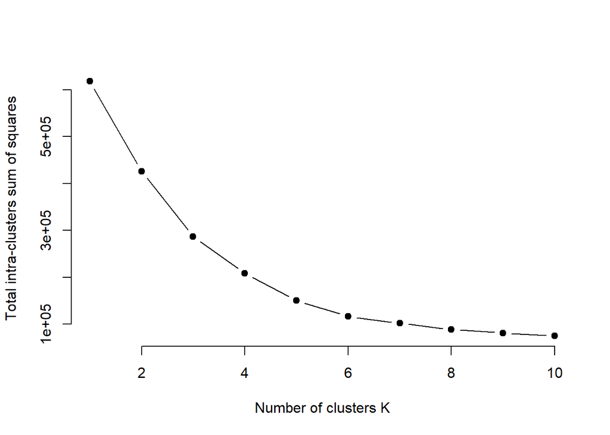

```r
library(purrr)
set.seed(123)
# function to calculate total intra-cluster sum of square
iss <- function(k) {
  kmeans(customer_data[,3:5],k,iter.max=100,nstart=100,algorithm="Lloyd" )$tot.withinss
}

k.values <- 1:10


iss_values <- map_dbl(k.values, iss)

plot(k.values, iss_values,
     type="b", pch = 19, frame = FALSE,
     xlab="Number of clusters K",
     ylab="Total intra-clusters sum of squares")


#Average Silhouette Method

library(cluster)
library(gridExtra)
```

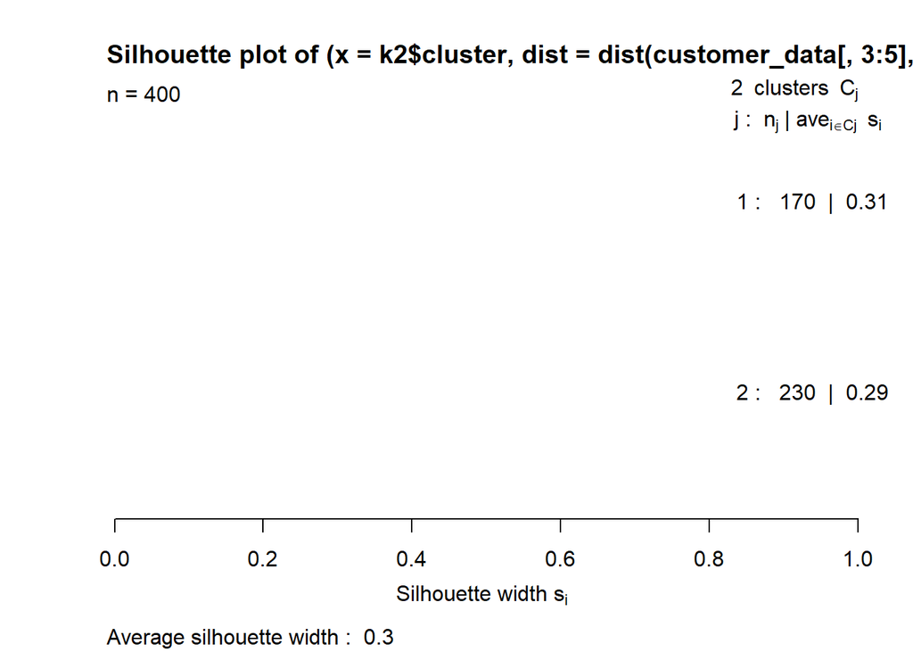

```r
library(grid)


k2<-kmeans(customer_data[,3:5],2,iter.max=100,nstart=50,algorithm="Lloyd")
s2<-plot(silhouette(k2$cluster,dist(customer_data[,3:5],"euclidean")))
```

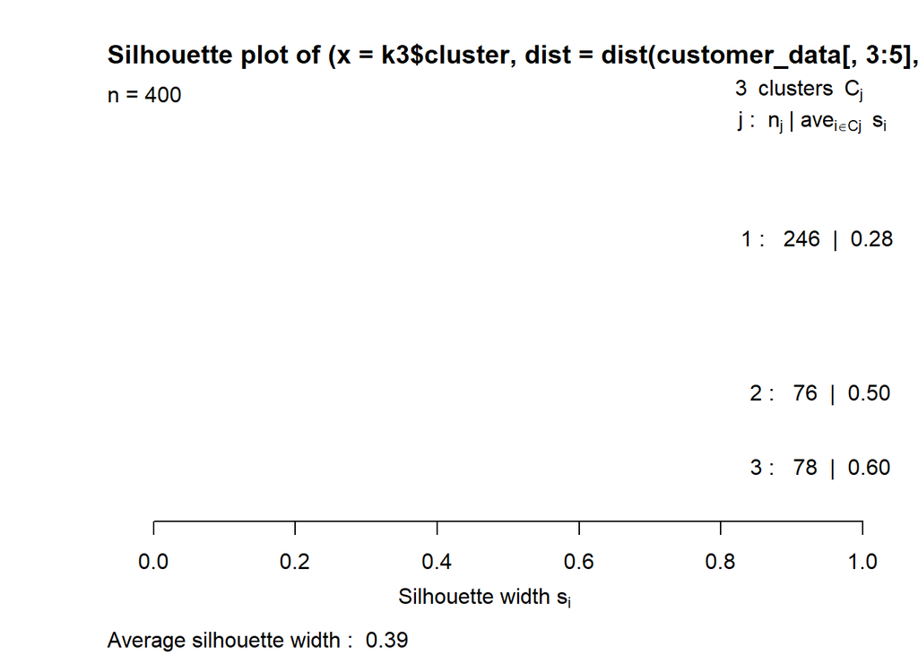

```r
k3<-kmeans(customer_data[,3:5],3,iter.max=100,nstart=50,algorithm="Lloyd")
s3<-plot(silhouette(k3$cluster,dist(customer_data[,3:5],"euclidean")))
```

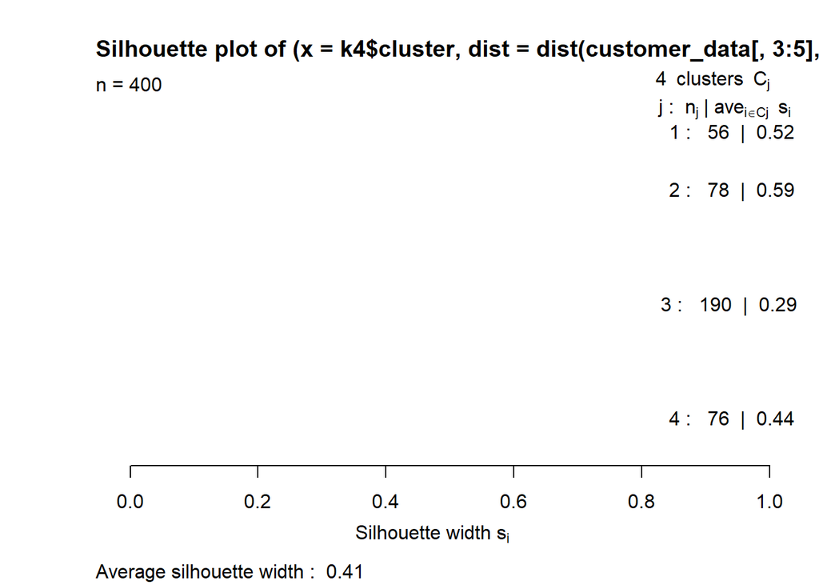

```r
k4<-kmeans(customer_data[,3:5],4,iter.max=100,nstart=50,algorithm="Lloyd")
s4<-plot(silhouette(k4$cluster,dist(customer_data[,3:5],"euclidean")))
```

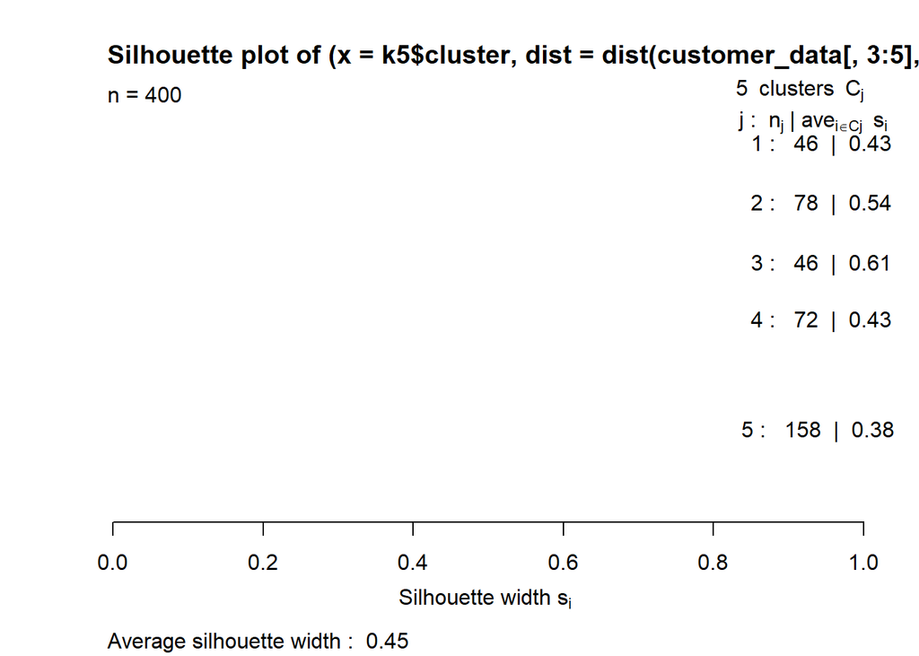

```r
k5<-kmeans(customer_data[,3:5],5,iter.max=100,nstart=50,algorithm="Lloyd")
s5<-plot(silhouette(k5$cluster,dist(customer_data[,3:5],"euclidean")))
```

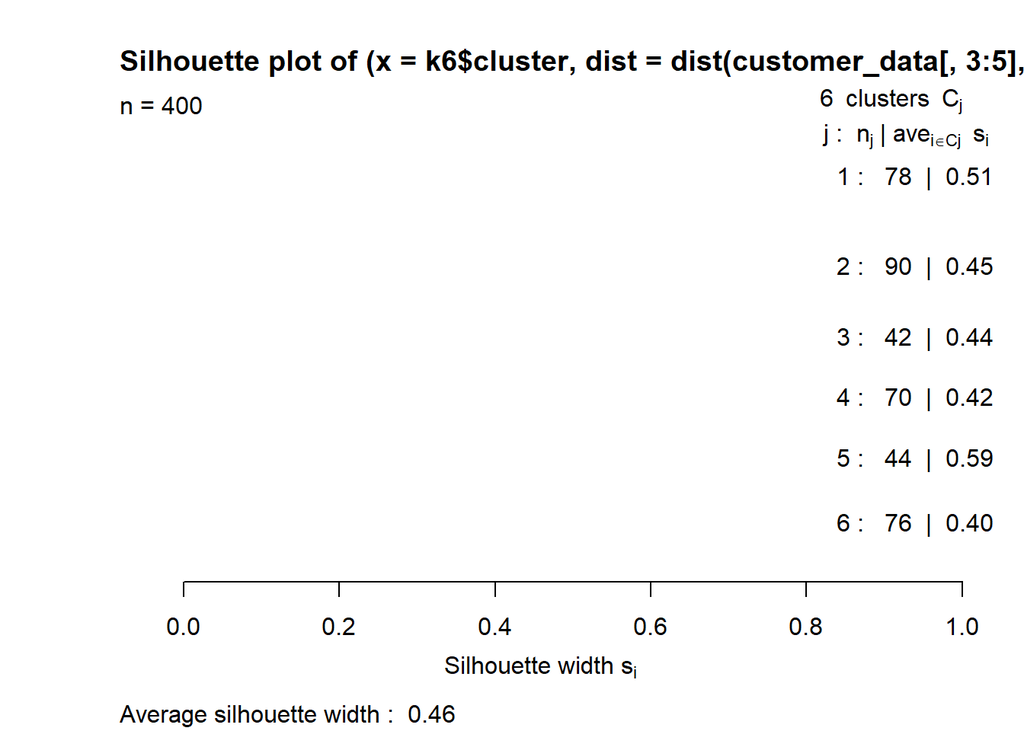

```r
k6<-kmeans(customer_data[,3:5],6,iter.max=100,nstart=50,algorithm="Lloyd")
s6<-plot(silhouette(k6$cluster,dist(customer_data[,3:5],"euclidean")))
```

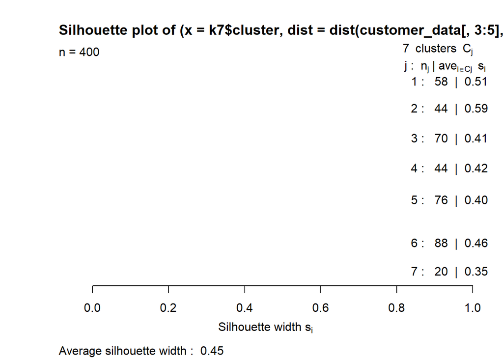

```r
k7<-kmeans(customer_data[,3:5],7,iter.max=100,nstart=50,algorithm="Lloyd")
s7<-plot(silhouette(k7$cluster,dist(customer_data[,3:5],"euclidean")))
```

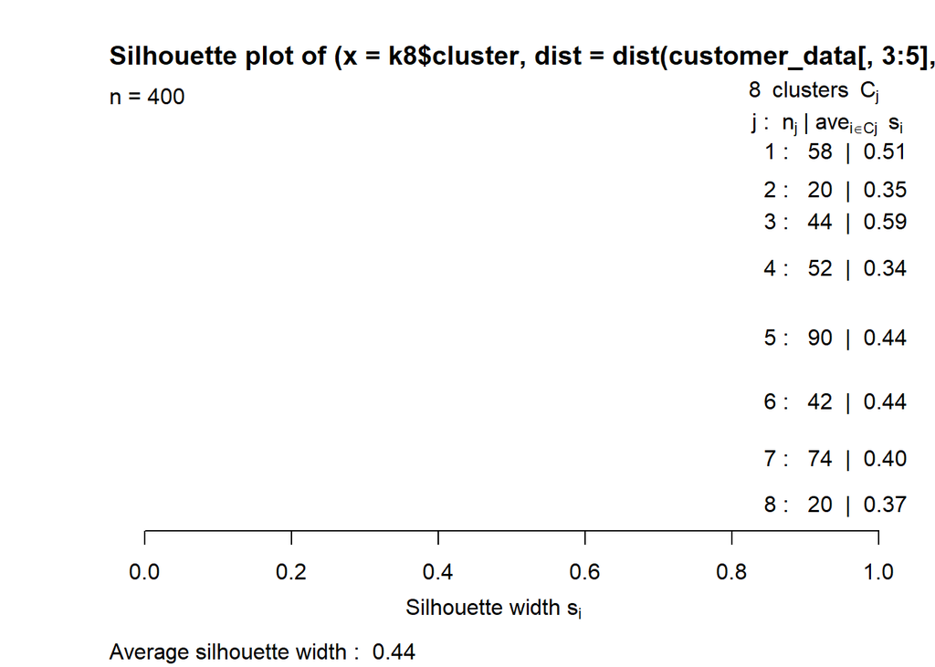

```r
k8<-kmeans(customer_data[,3:5],8,iter.max=100,nstart=50,algorithm="Lloyd")
s8<-plot(silhouette(k8$cluster,dist(customer_data[,3:5],"euclidean")))
```

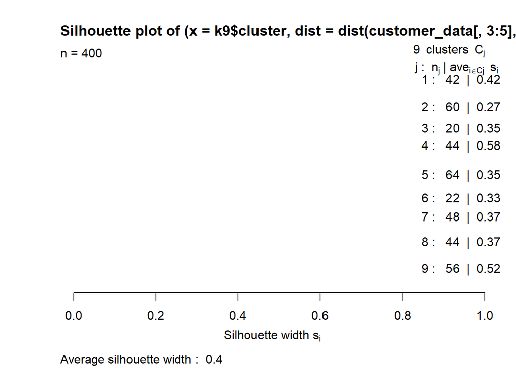

```r
k9<-kmeans(customer_data[,3:5],9,iter.max=100,nstart=50,algorithm="Lloyd")
s9<-plot(silhouette(k9$cluster,dist(customer_data[,3:5],"euclidean")))
```

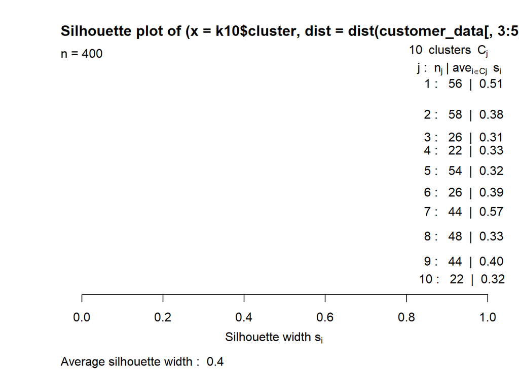

```r
k10<-kmeans(customer_data[,3:5],10,iter.max=100,nstart=50,algorithm="Lloyd")
s10<-plot(silhouette(k10$cluster,dist(customer_data[,3:5],"euclidean")))
```

```r
library(NbClust)
library(factoextra)
```

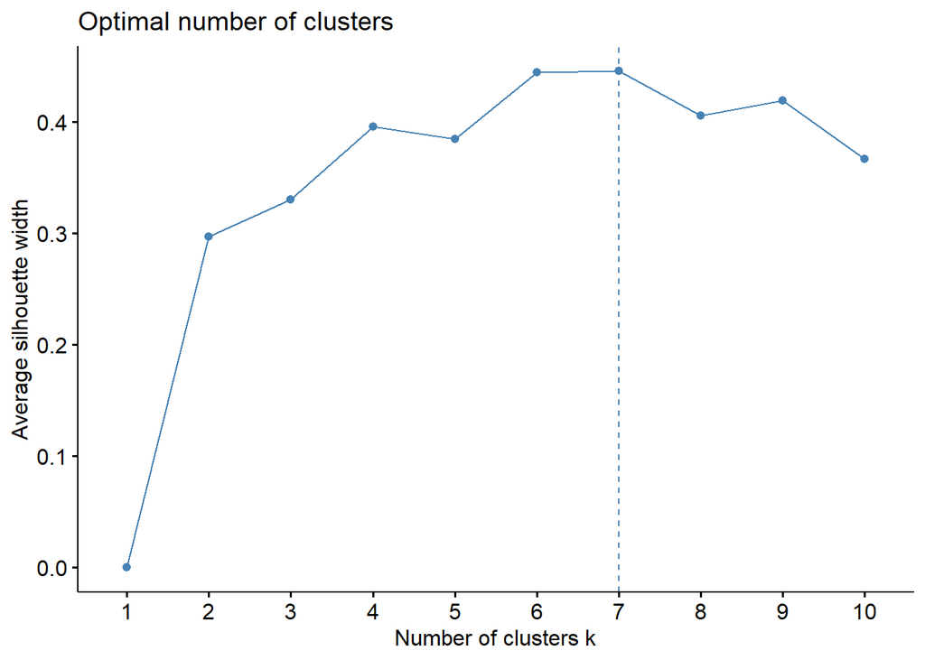

```r
fviz_nbclust(customer_data[,3:5], kmeans, method = "silhouette")
```

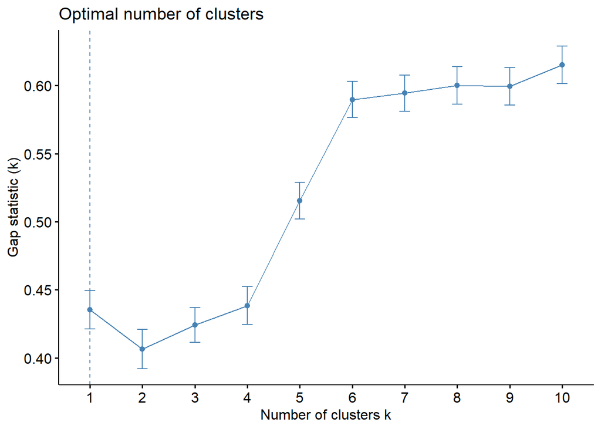

```r
set.seed(125)
stat_gap <- clusGap(customer_data[,3:5], FUN = kmeans, nstart = 25,
                    K.max = 10, B = 50)
fviz_gap_stat(stat_gap)
```

```r
k6<-kmeans(customer_data[,3:5],6,iter.max=100,nstart=50,algorithm="Lloyd")
k6
```

```
## K-means clustering with 6 clusters of sizes 90, 76, 44, 78, 70, 42
##
## Cluster means:
##        Age Annual.Income..k.. Spending.Score..1.100.
## 1 56.15556           53.37778               49.08889
## 2 27.00000           56.65789               49.13158
## 3 25.27273           25.72727               79.36364
## 4 32.69231           86.53846               82.12821
## 5 41.68571           88.22857               17.28571
## 6 44.14286           25.14286               19.52381
##
## Clustering vector:
##   [1] 6 3 6 3 6 3 6 3 6 3 6 3 6 3 6 3 6 3 6 3 6 3 6 3 6 3 6 3 6 3 6 3 6 3 6 3 6
##  [38] 3 6 3 1 3 1 2 6 3 1 2 2 2 1 2 2 1 1 1 1 1 2 1 1 2 1 1 1 2 1 1 2 2 1 1 1 1
##  [75] 1 2 1 2 2 1 1 2 1 1 2 1 1 2 2 1 1 2 1 2 2 2 1 2 1 2 2 1 1 2 1 2 1 1 1 1 1
## [112] 2 2 2 2 2 1 1 1 1 2 2 2 4 2 4 5 4 5 4 5 4 2 4 5 4 5 4 5 4 5 4 2 4 5 4 5 4
## [149] 5 4 5 4 5 4 5 4 5 4 5 4 5 4 5 4 5 4 5 4 5 4 5 4 5 4 5 4 5 4 5 4 5 4 5 4 5
## [186] 4 5 4 5 4 5 4 5 4 5 4 5 4 5 4 6 3 6 3 6 3 6 3 6 3 6 3 6 3 6 3 6 3 6 3 6 3
## [223] 6 3 6 3 6 3 6 3 6 3 6 3 6 3 6 3 6 3 1 3 1 2 6 3 1 2 2 2 1 2 2 1 1 1 1 1 2
## [260] 1 1 2 1 1 1 2 1 1 2 2 1 1 1 1 1 2 1 2 2 1 1 2 1 1 2 1 1 2 2 1 1 2 1 2 2 2
## [297] 1 2 1 2 2 1 1 2 1 2 1 1 1 1 1 2 2 2 2 2 1 1 1 1 2 2 2 4 2 4 5 4 5 4 5 4 2
## [334] 4 5 4 5 4 5 4 5 4 2 4 5 4 5 4 5 4 5 4 5 4 5 4 5 4 5 4 5 4 5 4 5 4 5 4 5 4
## [371] 5 4 5 4 5 4 5 4 5 4 5 4 5 4 5 4 5 4 5 4 5 4 5 4 5 4 5 4 5 4
##
## Within cluster sum of squares by cluster:
## [1] 16124.267 15485.789  8199.636 27944.718 33381.714 15464.762
##  (between_SS / total_SS =  81.1 %)
##
## Available components:
##
## [1] "cluster"      "centers"      "totss"        "withinss"     "tot.withinss"
## [6] "betweenss"    "size"         "iter"         "ifault"
```

**Visualizing the Results Using the first two Principle Components**

Cluster 5: Customers in this cluster have medium PCA1 and low PCA2 scores.

Through clustering, there is a comprehensive understanding of the variables, allowing for more informed decision-making. By identifying specific customer segments based on income, age, spending patterns, and other parameters, companies can better target their products and services. Additionally, the consideration of more complex patterns like product reviews contributes to improved segmentation and personalized offerings.

```r
pcclust=prcomp(customer_data[,3:5],scale=FALSE) #principal component analysis
summary(pcclust)
```

```
## Importance of components:
##                            PC1     PC2     PC3
## Standard deviation     26.4293 26.1269 12.9155
## Proportion of Variance  0.4512  0.4410  0.1078
## Cumulative Proportion   0.4512  0.8922  1.0000
```

```r
pcclust$rotation[,1:2]
```

```
##                               PC1        PC2
## Age                     0.1889742 -0.1309652
## Annual.Income..k..     -0.5886410 -0.8083757
## Spending.Score..1.100. -0.7859965  0.5739136
```

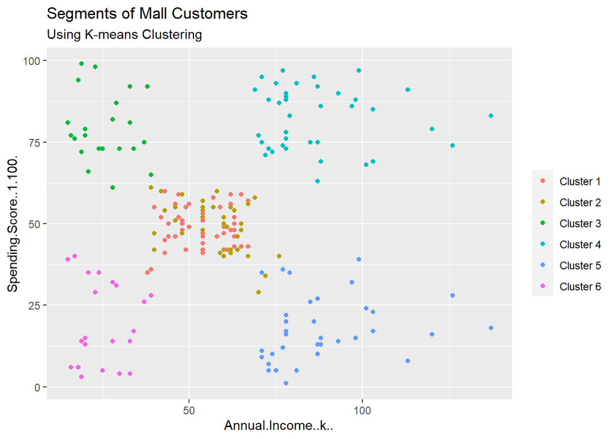

```r
set.seed(1)
ggplot(customer_data, aes(x =Annual.Income..k.., y = Spending.Score..1.100.)) +
  geom_point(stat = "identity", aes(color = as.factor(k6$cluster))) +
  scale_color_discrete(name=" ",
                       breaks=c("1", "2", "3", "4", "5","6"),
                       labels=c("Cluster 1", "Cluster 2", "Cluster 3", "Cluster 4", "Cluster 5","Cluster 6")) +
  ggtitle("Segments of Mall Customers", subtitle = "Using K-means Clustering")
```

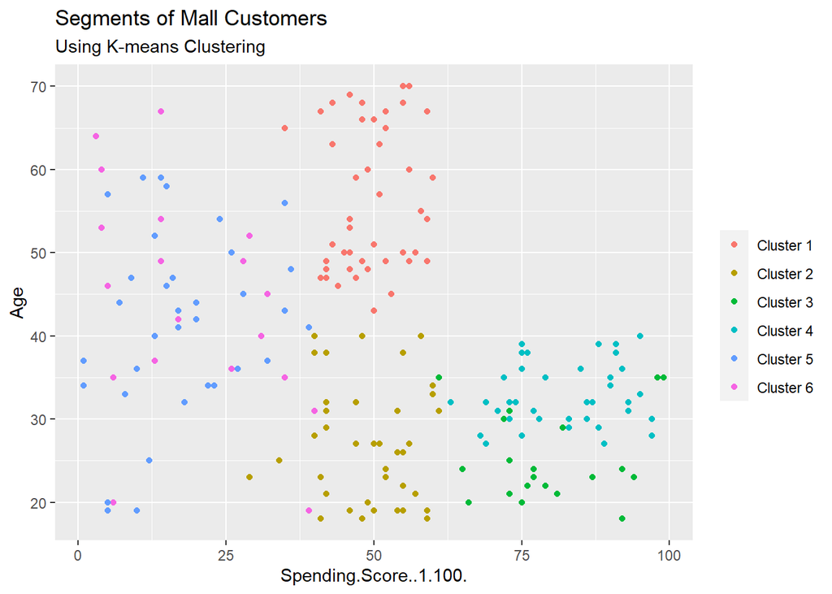

```r
ggplot(customer_data, aes(x =Spending.Score..1.100., y =Age)) +
  geom_point(stat = "identity", aes(color = as.factor(k6$cluster))) +
  scale_color_discrete(name=" ",
                       breaks=c("1", "2", "3", "4", "5","6"),
                       labels=c("Cluster 1", "Cluster 2", "Cluster 3", "Cluster 4", "Cluster 5","Cluster 6")) +
  ggtitle("Segments of Mall Customers", subtitle = "Using K-means Clustering")
```

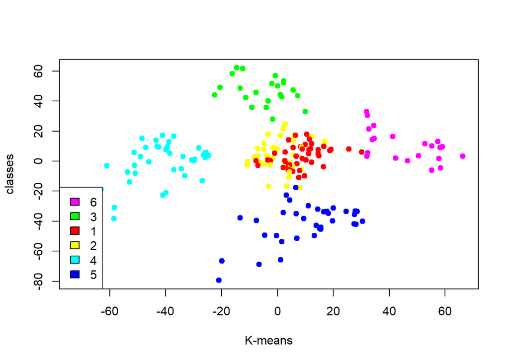

```r
kCols=function(vec){cols=rainbow (length (unique (vec)))
return (cols[as.numeric(as.factor(vec))])}

digCluster<-k6$cluster; dignm<-as.character(digCluster); # K-means clusters

plot(pcclust$x[,1:2], col =kCols(digCluster),pch =19,xlab ="K-means",ylab="classes")
legend("bottomleft",unique(dignm),fill=unique(kCols(digCluster)))
```

**SUMMARY**  
The customer segmentation project successfully implemented the K-means clustering algorithm to divide the customer base into distinct groups based on income and spending patterns. This approach allowed for targeted marketing strategies and a deeper understanding of customer preferences. The project started with data exploration and visualization of customer characteristics such as gender, age distribution, and annual income. The insights gained from these visualizations provided valuable information about the customer base. The K-means algorithm was then employed to create clusters based on customer income and spending patterns, enabling businesses to develop tailored marketing strategies. Overall, the customer segmentation project demonstrated the benefits of understanding customer segments and highlighted the potential for optimizing marketing efforts and improving decision-making processes.

**LIMITATIONS**  
Limited Variables: The project focused on a specific set of variables such as gender, age, and income. This limited scope may not capture all relevant factors that influence customer behavior, potentially leading to oversimplification and incomplete segmentation.

**CONCLUSION**  
In conclusion, the customer segmentation project using the K-means clustering algorithm has successfully divided the customer base into distinct groups based on income and spending patterns. This segmentation approach can allow businesses to implement targeted marketing strategies and gain a deeper understanding of customer preferences. By tailoring marketing efforts to specific customer segments, businesses can optimize their marketing campaigns and drive better results. The project highlights the benefits of customer segmentation in enhancing marketing effectiveness and overall business success. Going forward, the insights gained from this project can serve as a valuable foundation for further research and implementation of customer segmentation strategies to drive customer satisfaction and business growth.

**Pius Mithika**  
**Data Scientist**